# Intro to Version Control with Git

Author

Bolívar Aponte Rolón  
*created by*: William Wilber  
and Steve Formel

Published

Last updated on September 26, 2023

## Objective

This tutorial will teach you the basics of version control and track the history of your projects (i.e. R scripts) with Git in *Windows*, *Mac* and *Linux*. We will then learn how to share code and collaborate through GitHub.

## What is version control?

We are familiar with this concept some way or another. Some of us save multiple version of our code or manuscripts, culminating in the infamous “manuscript_FINAL_FINAL_VERSION.docx” or similar. Others make copies of files in another directory “just in case”. This is a rudimentary form of version control that works, but we can agree it is cumbersome.

To overcome this challenges, programmers developed various form of version control, but all can be summarized as a “system that record changes to a file or set of files over time” allowing recall to specific version later on (Chacon & Straub, 2014).

Git is a version control tool that lets users track the history of the project so that previous versions are never lost. This is great for collaboration as well as non-collaborative projects when we need to keep track of our edits. Recently, there is interest for Ecology and Evolutionary Biology (surely applicable to other fields as well) to use Git and GitHub (or similar) to improve research workflows, collaboration, transparency and open research (see Braga et al., 2023).

### Prerequisites

- Install Git
- Register an account on [GitHub](https://github.com/).
- Download [GitHub Desktop](https://desktop.github.com/)

## Installing Git

Let’s check if you have Git installed already. For MacOS and Linux, begin by opening a terminal (MacOS) or or console your Linux distribution.

### Mac OS

Check whether Git is installed with the command:

`git --version`

- **In MacOS** it should automatically prompt you to install Git if it is not available. See [here](https://git-scm.com/book/en/v2/Getting-Started-Installing-Git) for more details.

#### Install with Homebrew

Using the [Homebrew](https://brew.sh/) package manager you can follow these commands to install Git:

1. Open your terminal and install Git using Homebrew:

`brew install git`

2. Verify the installation was successful by typing `git --version`

You should see the most recent version installed.

### Linux (Debian/Ubuntu)

1. Open up the terminal (shell) and install git with the command:

`sudo apt install git-all`

2. Verify the installation was successful by typing `git --version`

This command may vary depending on your Linux distribution. See [this link](https://git-scm.com/download/linux) for detailed instructions on what command to use.

### Windows

1. Download the [Windows installer](https://gitforwindows.org/)
2. Follow the prompts.
3. Open a Command Prompt (or Git Bash if during installation you elected not to use Git from the Windows Command Prompt).

**Note**

For Windows users, you may also consider a Linux environment which can be installed on Windows 10 computers. To install Linux in Windows, follow the instructions provided [here](https://docs.microsoft.com/en-us/windows/wsl/install-win10).

## Configuring Git

First we will **configure Git with our GitHub account details**. GitHub is a hosting solution that allows us to easily share our Git repositories with other users. In doing so it also serves a cloud storage for your repositories in case something happens to your local machine.

**Warning**

Go back and open a GitHub account if you haven’t done so. We will be using it in the next part of the tutorial and in Part 2.

To set your account details in git:

`git config --global user.name "Your GitHub username"`

`git config --global user.email "Your GitHub account email"`

Git can also operate independently of GitHub, or with other hosting options such as [BitBucket](https://bitbucket.org/) or [GitLab](https://about.gitlab.com/).

We can also **set our default command line text editor** for Git. By default, Git will use the Vim editor on the command line. Command line text editors can be confusing for users who are not used to working in this environment. I recommend using nano for those that are new to the command line, but Vim provides a more robust experience for those that are open to learning a new tool.

`git config --global core.editor "nano -w"`

`git config --global core.editor "vim"`

You can check your configuration with the command:

`git config --list`

## Your first repository

A repository is where Git saves the old versions of our files. We make repositories inside of the directory that we are working in. **Let’s start by making a new working directory**. I will provide command line code for those that are new to working this way.

`mkdir twerc_git`

`cd twerc_git`

`git init`

**Note**

You should see text in parenthesis (e.g. “(Main)”) at the end of the path to your working directory. If not, we have to configure “global’ options for the repository. See below.

Now let’s create a test file.

`touch test.md`

The `touch` command creates the file. This command creates a new text file “test.md” that can be opened with the text editor of your choice, either at the command line or with a GUI based editor like Word or Notepad.

Let’s see our new repository in the directory, use the command:

`ls -a`

You will see an output like this:

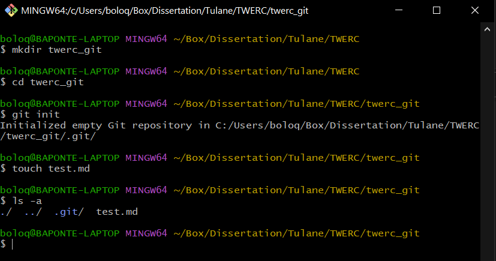

Figure 1. Newly created file

See the `test.md` file we just created.

The `.git` directory indicates that a repository has been created for your working directory. All sub-directories within your working directory will also be backed up in this repository as long as you the Git to track them.

We can also **check the project status** with the command:

`git status`

You will see this output:

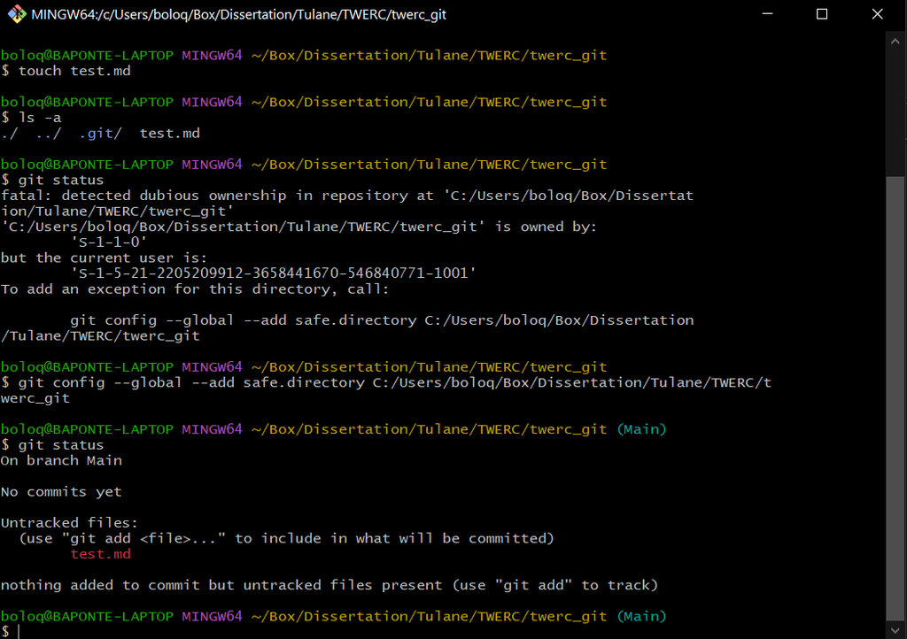

Figure 2. Untracked “test” file.

In this example, `git status` prompted and error message after detection of a “dubious” ownership (Figure 2). Copy and paste into the command line the exception command offered by Git. After this, enter `git status` again.

The “test.md” is marked as “untracked”. This simply means this file is new to the directory and has not yet been added to the repository.

For now, this means all is good! We will be returning to this status screen often.

## Tracking file changes

Now we are on to the bread and butter of using Git. Make sure that you are still in your “twerc_git” directory before proceeding. You can check your current directory with the command `pwd`. This is important because ewe don’t want to start a repository in the wrong directory or our computer’s root directory.

We already created a file called `test.md`. Now let’s modify it with `nano`:

`nano test.md`

Enter some text into the file, then exit `nano` with `Ctrl + x`. Nano will automatically prompt you to save when exiting.

We can **track a new file** with the command:

`git add test.md`

Let’s again **check the project status**:

`git status`

Let’s check the project status:

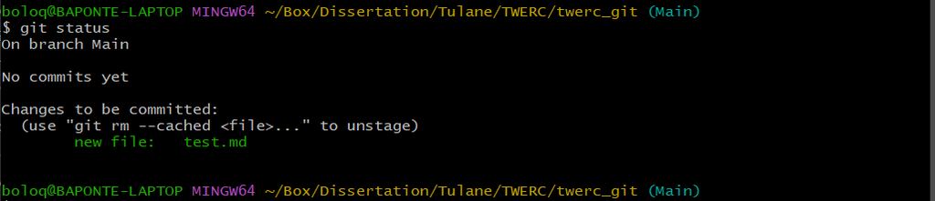

Figure 3. Status of “test’ file after staging.

**Tip**

You can start tracking your file from the start or at any point in your project’s history. Git does not track files unless you tell it. If you want all the files in a directory to be tracked, you can type:

`git add .`

or

`git add -all`

This last command will track all files in the repository directory, including hidden files.

##### Commiting changes

When we used `git add test.md` started tracking the file. The new file is now being tracked but has not yet been “committed”.

Committing a change creates a snapshot of your file at that time and stage. Each “commit” is a preserved state of your project that can be recalled in the future. The commit command will preserve any changes that have been “added” to the staging area.

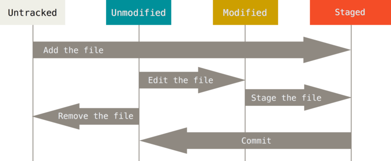

Figure 4. The lifecycle of the status of your files

Let’s try.

We can **commit our changes** with the command:

`git commit -m "ADD A DESCRIPTION HERE"`

The “descriptive message” is created by the argument `-m`, short for “message”. It should be a short and clear statement about the changes that were made, so that it’s easy to identify the changes associated with the that particular commit later on. If you do not enter the `-m` argument Git will automatically open your default text editor so you can write a longer message detailing the changes in the commit. Spending a few extra seconds writing a good descriptive message will help you and others understand the history of the project. Think of it as good class notes!

After you’ve run this command, check your `git status` again and your repository is now current with the status of your directory.

To **see a log of the commits we’ve made**, we can use the command:

`git log`

The output of this command will show you who made the commit, when the commit was made, the branch it occured in, and the descriptive message you entered when you made the commit. It contains the `checksum` associated with each commit. It is a unique identification number that Git creates when all changes have been successfully stored. This number will be different for each local machine.

Let’s edit the file again to see how Git tracks changes between versions. Open the text file and change the contents, then save the file and close it.

## Showing Changes In Repository

To **view the changes** between the edits you’ve made and what was saved in your last commit, use the command:

`git diff`

Look at the output of this command and understand where it’s showing you what has been removed and what has been added. The previous version (marked a/test.md) and the current version (b/test.md). Additions to the file are indicated with a “+” and deletions with a “-” at the beginning of the line (Allesina & Wilmes, 2019).

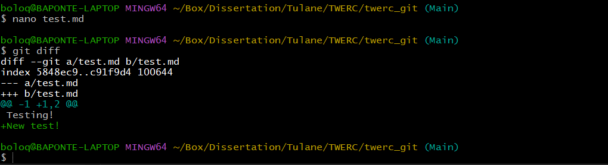

Figure 5. Output of `git diff`

Let’s commit this change before moving on:

`git add test.md`

`git commit -m "DESCRIPTIVE MESSAGE"`

`git status`

#### Let’s Practice

We can **control what files in our directory are added to any given commit** with selective use of the add function. Let’s make a new file to see how this works:

`touch new_test.md`

Now edit the text in both the first and second text files and save your changes.

Add each file to the staging area and commit them.

`git add test.md new_test.md`

Once you’ve done this, check your `git status` to see that your working directory is synced with your most recent commit, and use `git log` to see all of the changes you’ve done so far.

Your output should look something like this:

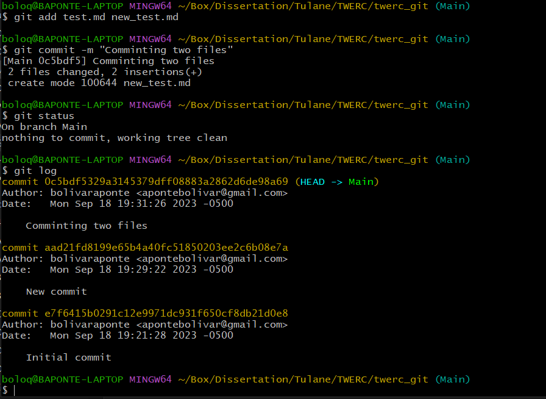

Figure 6. Full commit list.

## Amending an Incomplete Commit

Sometimes we forget to add a file to our commit command or we forgot to change that crucial line in our code. How do we fix that? We have two options: 1) ammend our commit, 2) “unstage” our file

#### Amending our commit

We can add the modified file or file that we had forgotten by running:

`git add forgottenfile.txt`

`git add fixedcode.R`

`git commit --amend`

This will include your files in the previous commit. Of course, you can always just do a new commit with the files you missed but this creates many small commits that can be annoying.

#### Unstaging Files

We can “unstage” file when we do no intend on including a certain files or commiting the changes made. Git provide helpful suggestions on how to do this. When working in a local repository we can check with `git status` and it will look like this:

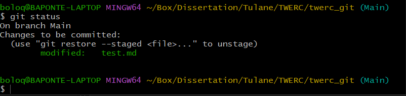

Figure 7. Git suggestion on how to unstage files

Run command:

`git restore --staged <file>`

## Comparing commits and returning to old commits

Each commit in your git log has a unique commit ID. We can use these IDs to **compare the changes that have been made between commits**. Let’s try this now. Copy the commit number of your first commit and then use this command:

`git diff commit #`

You will get an extended log of what we saw previously with the `diff` command, showing all of the changes that have been made since the first commit.

This output shows us the changes we have made in painful detail. How can we fix the problems that we’ve made for ourselves? We can **restore a desired version of a file** with the checkout command.

To restore to the last commit, run:

`git checkout test.md`

If you need to restore to a specific commit version, run:

`git checkout commit# test.md`

**Remember that “commit#” just refers to the commit number given when you run `git log`.**

Woohoo! Let’s commit this change so that the most recent commit contains both versions of the commit we desire.

This is all we will cover on the core functionality of Git today. For a more comprehensive tutorial exploring how to create and merge branches check out the [Software Carpentry website.](https://swcarpentry.github.io/git-novice/) I highly recommend working through the rest of it on your own or with a partner!

## Collaborating with GitHub

Tracking changes in your local repository is a good practice, especially so when you are collaborating with others. Projects with collaborators are important and nobody wants be the one who delete a file by mistake. For this purpose software developers and scientist use Github to share there code, collaborate and promote reproducibility. GitHub is merely a service that allows us to easily share out git repos with our collaborators. You can host fully remote repositories as well as connect your local repository with a remote. To achieve this we will learn a few more commands to translate working with Git to working with GitHub.

**Tip**

You should all have GitHub accounts. If not, pause and create one.

When you have a collaborative project you will want to set up your repository online in GitHub. Collaborators will need to `clone` the repository to participate and contribute. Let’s do that now!

Go to the GitHub repository for today’s lesson:  
https://github.com/TulaniansWERC/GitTut_2023.git

[figure not shown]

Figure 8. TWERC Repo

You want to **clone this repository** to your computer. Navigate to the `twerc_git` directory we created before or one above it (Wherever you feel like cloning a repository). Copy the HTTPS address given on the webpage or type it in manually in the command line.

`git clone https://github.com/TulaniansWERC/GitTut_2023.git`

Now navigate into this new directory. Let’s use `ls -a` and `git status` to check that this directory has a git repository associated with it. We should see a `.git` file.

How does this local repository communicate with GitHub? It uses a remote, which links it to the GitHub repo. We **can see what remotes are associated with a repo** with the command:

`git remote -v`

This shows us the name of the remote and where it is addressed to. Remotes tell Git where to “push” and “pull” from.

**Warning**

You might be prompted to add the cloned repository to your global configurations. Follow Git’s prompt suggestions that should go somewhat like this:

`git config --global --add safe.directory <PATH/TO/REPO>`

**Note**

Not every cloned repository will allow you to `push` and `pull`. The administrators of said repositories establish who contributes or not. Make sure you are authorized to collaborate with a project or repository by contacting the administrators of it.

Now we all have the same directory. How do we share the changes that we make with each other? We will work with this repo the same as we would any other, we just have to add one extra step at the end.

*I will show you one example first before you try.*

Now that I have pushed my commit up to GitHub, you will need to pull my changes down so that you have the most recent commit. **This completes the basic GitHub workflow:**

```bash
# Updates your repo to the most recent version.
$ `git pull origin master`

# Edit the files you wish to change; when done run:
$  `git add editedfile.extension`

# or

$ git add --all

# Commit
$ `git commit -m "commit message"`

#Push (publish) your changes

$ `git push origin master`
```

**Note**

Keep in mind that he “master” branch name can differ (e.g. main, default, etc.).

## GitHub Desktop

We’ve learned a lot and if we were not comfortable working in a command line interface I hope this has helped. All that we did is also achieved through a graphical user interface (GUI). In this case GitHub Desktop.

Let’s open our GitHub desktop application. We can add the cloned repository to the GUI and see all the changes and files like we normally interact with file explorer.

### Add the cloned repository.

1. Go to **File** tab.
2. Select **Add local repository**
3. Find the path to the repository.

If we haven’t made any changes the set up should look like this:

[figure not shown]

Figure 9. GitHub Desktop workspace

The work space is divided in a left file panel where you can see the files in the repository and write a commit message. On the right hand panel you will see the contents of the file and change (addition or deletions) to it.

### Clone a repository from GitHub Desktop

1. Go to **File** tab.
2. Select **Clone repository**
3. In the pop-up window, select the **URL** tab
4. Paste the **URL** for the repository you want under **Repository URL or GitHub username and repository**
5. Under **Local Path**, select where you want to clone the repository to.

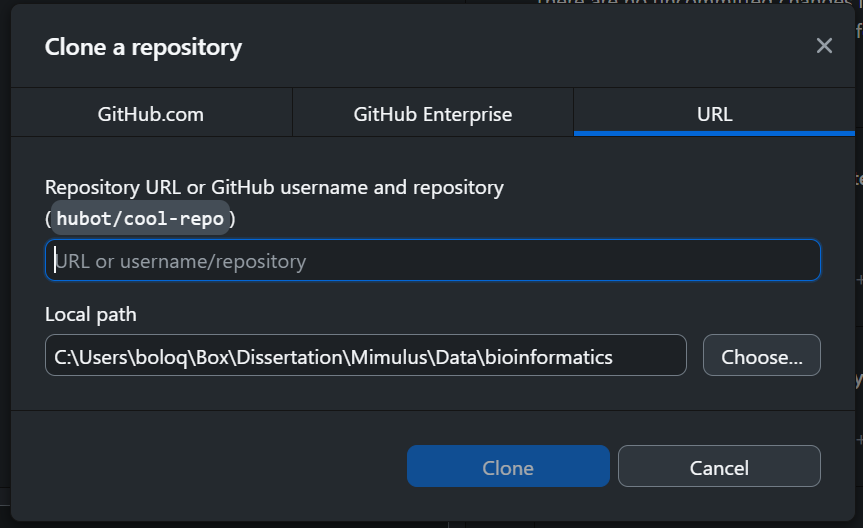

Figure 10. GitHub Desktop Clone repo window

### GitHub Desktop Workflow

When you are working with a remote repository, whether through the CLI or the desktop application, you will follow same workflow presented in the previous section. Before starting any changes you “pull” (or “fetch”) any new updates from your remote to your local repository. Make changes, commit and “push” your changes. Now you have a visual aid to understand the commands!

[figure not shown]

Figure 11. GitHub Desktop header

#### Staging and commiting files

By checking the file changes your are “staging” your file for the next commit. A modified file is indicated by the orange square in the far right side in the left file panel.

You can select all the file you want to commit, write a message and click **Commit to main** (or any other branch name).

Git hub Desktop will tell you that no uncommitted changes are detected in the repository and prompt you to “push” to origin.

[figure not shown]

If the remote is set up correctly (it should because we cloned it!) it will push our changes and our collaborator can see.

### R Studio and Rproj

We can continue to make changes and pull and push changes via the CLI or GitHub Desktop, but We can link our repository to R Studio via and R Project. This potentially minimizes windows and applications open and it can all be done from one integrated development environment (IDE). It’s more user friendly!

Steps

1. Open **R Studio**
2. Create a **.Rproj** file by going to the upper right corner and selecting the R-in-blue-box icon.
3. From the drop down menu, select **New Project**

[figure not shown]

Figure 13. R Studio: Creating a new .Rproj

4. Because we are working with an existing repository, select **Existing Directory** from the *New Project Wizard* window.
5. Similar to GitHub Desktop, browse and add the repository path.
6. Click **Create Project**

Your work space will take a couple of seconds to load the new project. It should have the same name as your repository. You can always change it later, if you prefer!

Now your R Studio window should looks like this (notice circled in red):

[figure not shown]

Figure 14. New feature in R Studio window

These are some of the changes you will see when working in an `.Rproj`. You will have multiple ways of pulling, commiting and pushing your changes all while working from your R Studio.

[figure not shown]

Figure 15. The options are endless

Once you have made all your changes, select **commit** from any of the tabs and you will see this window:

[figure not shown]

Figure 16. Another commit window

Folow the same workflow as explained before and you will be a version control master!

That’s probably all we’re getting through today! If we have time I can show you how conflicts between commits are resolved and how to initialize your own remotes. Thanks for coming!

## References

Allesina, S., & Wilmes, M. (2019). *Computing skills for biologists: A toolbox*. Princeton University Press. http://www.jstor.org/stable/j.ctvc77jrc

Braga, P. H. P., Hébert, K., Hudgins, E. J., Scott, E. R., Edwards, B. P. M., Sánchez Reyes, L. L., Grainger, M. J., Foroughirad, V., Hillemann, F., Binley, A. D., Brookson, C. B., Gaynor, K. M., Shafiei Sabet, S., Güncan, A., Weierbach, H., Gomes, D. G. E., & Crystal‐Ornelas, R. (2023). Not just for programmers: Not just for programmers: How GitHub can accelerate collaborative and reproducible research in ecology and evolution. *Methods in Ecology and Evolution*, *14*(6), 1364–1380. https://doi.org/10.1111/2041-210X.14108

Chacon, S., & Straub, B. (2014). *Pro git* (2nd ed.). Apress.

- https://swcarpentry.github.io/git-novice/
- https://git-scm.com/book/en/v2/Git-Basics-Recording-Changes-to-the-Repository